# Fin Stage

2025-09-02

On a defini nos sites par des mailles de 10kmx10km sur l’ensemble de la Bretagne. On a retire les sites dont l’aire est strictement inferieure a $10 km^2$. On obtient ainsi 317 sites au total.

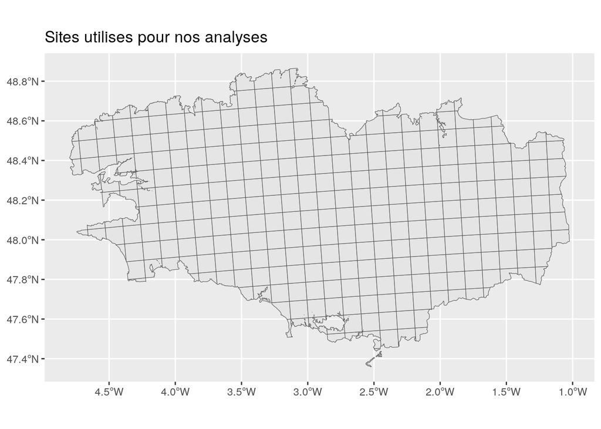

```r
VariablesSite%>%
  ggplot()+geom_sf()+labs(title = "Sites utilises pour nos analyses")
```

# 1 Regressions

On a fait des regressions lineaires avec la proportion de l’espece sur un site chaque annee $t$ en question, en lien avec d’autres especes. On a inclus diverses variables telles que :

- l’annee en qualitatif ou en quantitatif selon le cas, ainsi que l’annee au carre si applicable.
- des variables d’environnement comme la distance au littoral, la densite de cultures, etc.
- la proportion a l’annee precedente $t-1$, ainsi qu’a $t-2$, afin de reduire l’autocorrelation.

Nous avons utilise le BIC pour choisir le modele optimal. Cependant, bien que la plupart des resultats etaient coherents avec ce que l’on peut observer, les modeles ne semblaient pas valider les hypotheses necessaires aux GLM (residus et differents tests).

De plus, comme nous utilisons une espece temoin, cela peut affecter le modele. Nous sommes donc passes a des modeles d’occupancy.

# 2 Modeles Occupancy

Nous avons teste differents modeles d’occupancy sur plusieurs especes. Celles qui nous ont le plus interessees sont :

- le sanglier ;
- le renard ;
- le lapin ;
- le herisson ;
- le putois ;
- l’hermine ;
- la fouine.

Selon la bibliographie, les especes moins frequemment observees donnent de meilleurs resultats avec des periodes plus longues. Nous avons donc separe les especes soit en 5 periodes de 3 ans, soit en 3 periodes de 5 ans. Dans ce cas, le putois, l’hermine et la fouine sont les especes les moins facilement detectables qui aurons des periodes plus longues sur cette analyse.

Nous utilisons les memes variables d’environnement que pour les GLM, auxquelles nous ajoutons la variable pression d’observation, qui prend en compte le nombre d’observations autres que l’espece etudiee, par site et par annee.

```r
    quali_periodes_matrice_5 <-
      matrix(c('2010 - 2012', '2013 - 2015',
               '2016 - 2018', '2019-2021', '2022 - 2024'),
             nrow = 317,
             ncol = 5,
             byrow = TRUE)

    quanti_periodes_matrice_5 <- matrix(
      1:5,
      nrow=317,
      ncol=5,
      byrow=TRUE)
```

```r
    quali_periodes_matrice_3 <-
      matrix(c('2010 - 2014','2015 - 2019', '2020 - 2024'),
             nrow = 317,
             ncol = 3,
             byrow = TRUE)

    quanti_periodes_matrice_3 <- matrix(
      1:3,
      nrow=317,
      ncol=3,
      byrow=TRUE)
```

```r
    site_covs_periodes_5 <- list(
      quanti_periodes = quanti_periodes_matrice_5,
      quali_periodes = quali_periodes_matrice_5
    )

    site_covs_periodes_3 <- list(
      quanti_periodes = quanti_periodes_matrice_3,
      quali_periodes = quali_periodes_matrice_3
    )
```

## 2.1 Le sanglier

```r
    detection_matrice <- matrice_occu_detections(num_cd_nom = 60981)

    umf <- unmarkedFrameOccu(y = detection_matrice,
                             siteCovs = site_info)
```

On observe de plus en plus de sites ou le sanglier est present :

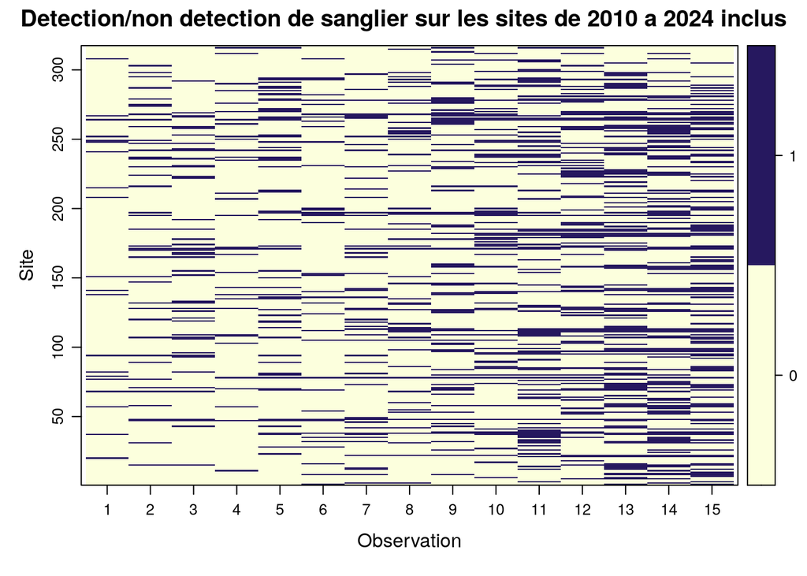

```r
    plot(umf,
         main="Detection/non detection de sanglier sur les sites de 2010 a 2024 inclus")
```

```r
    print(colSums(detection_matrice))
```

```
## 2010 2011 2012 2013 2014 2015 2016 2017 2018 2019 2020 2021 2022 2023 2024
##   20   41   45   32   59   38   51   53   73   71   94   90  116  114  120
```

```r
    pression_obs <- pression_obs_bdd(num_cd_nom = 60981)

    umf <- unmarked::unmarkedMultFrame(
      y = detection_matrice,
      siteCovs = site_info,
      obsCovs = list(pression_obs = pression_obs ),
      yearlySiteCovs = site_covs_periodes_5,
      numPrimary = 5
    )
    fm <- unmarked::colext(
      psiformula = ~ X_10km + Dnst_Cultures,     # initial occupancy
      gammaformula =  ~ 1,  # colonization
      epsilonformula = ~ 1, # extinction
      pformula = ~ pression_obs,  # detection
      data = umf, # data
      control = list(trace = 1),
      se = TRUE)
```

coefficients :

```r
    fm
```

```
##
## Call:
## unmarked::colext(psiformula = ~X_10km + Dnst_Cultures, gammaformula = ~1,
##     epsilonformula = ~1, pformula = ~pression_obs, data = umf,
##     se = TRUE, control = list(trace = 1))
##
## Initial (logit-scale):
##               Estimate    SE     z P(>|z|)
## (Intercept)     -0.502 0.165 -3.04 0.00237
## X_10km           0.549 0.186  2.95 0.00314
## Dnst_Cultures   -0.447 0.181 -2.47 0.01356
##
## Colonization (logit-scale):
##  Estimate    SE     z P(>|z|)
##    -0.211 0.143 -1.48    0.14
##
## Extinction (logit-scale):
##  Estimate    SE     z  P(>|z|)
##     -2.59 0.347 -7.46 8.34e-14
##
## Detection (logit-scale):
##              Estimate     SE     z  P(>|z|)
## (Intercept)    -0.839 0.0576 -14.6 3.84e-48
## pression_obs    0.968 0.0664  14.6 3.26e-48
##
## AIC: 4286.424
## Number of sites: 317
```

```r
    backTransform(fm, "col"); confint(backTransform(fm, "col"))
```

```
## Backtransformed linear combination(s) of Colonization estimate(s)
##
##  Estimate     SE LinComb (Intercept)
##     0.447 0.0354  -0.211           1
##
## Transformation: logistic
```

```
##      0.025     0.975
##  0.3793836 0.5173123
```

```r
    backTransform(fm, "ext"); confint(backTransform(fm, "ext"))
```

```
## Backtransformed linear combination(s) of Extinction estimate(s)
##
##  Estimate     SE LinComb (Intercept)
##      0.07 0.0226   -2.59           1
##
## Transformation: logistic
```

```
##       0.025     0.975
##  0.03675048 0.1292391
```

tests :

```r
    pb <- parboot(fm, statistic=chisq, nsim=40, parallel=FALSE)
```

```r
    pb
```

```
##
## Call:
## parboot(object = fm, statistic = chisq, nsim = 40, parallel = FALSE)
##
## Parametric Bootstrap Statistics:
##     t0 mean(t0 - t_B) StdDev(t0 - t_B)
## 1 4320           -437               56
##   Pr(t_B > t0)
## 1        0.976
##
## t_B quantiles:
##        0% 2.5%  25%  50%  75% 97.5% 100%
## [1,] 4594 4652 4738 4760 4786  4862 4885
##
## t0 = Original statistic computed from data
## t_B = Vector of bootstrap samples
```

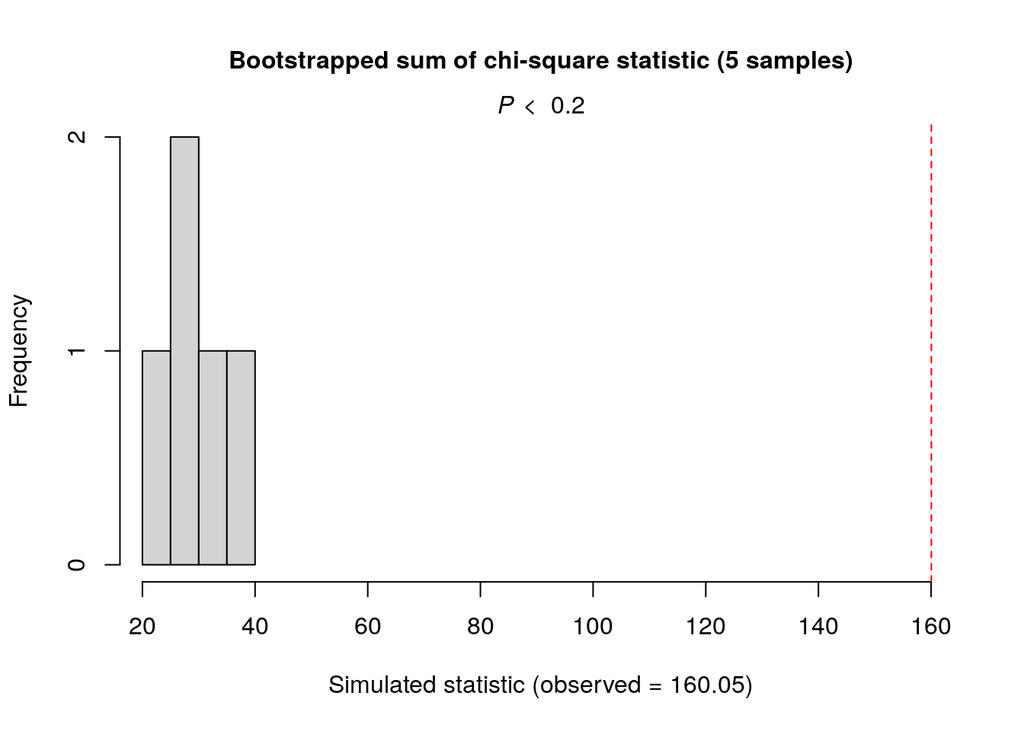

```
##
## Goodness-of-fit for dynamic occupancy model
##
## Number of seasons:  5
##
## Chi-square statistic:
## Season 1 Season 2 Season 3 Season 4 Season 5
##  20.8830  28.0490  17.8019  17.0955  76.2160
##
## Total chi-square = 160.0453
## Number of bootstrap samples = 5
## P-value = 0
##
## Quantiles of bootstrapped statistics:
##   0%  25%  50%  75% 100%
##   22   27   28   33   39
##
## Estimate of c-hat = 5.4
```

```r
    AICcmodavg::mb.gof.test(fm)
```

graphiques :

```r
plot <- proba_graphique_5(fm, couleur=couleur_sanglier)
```

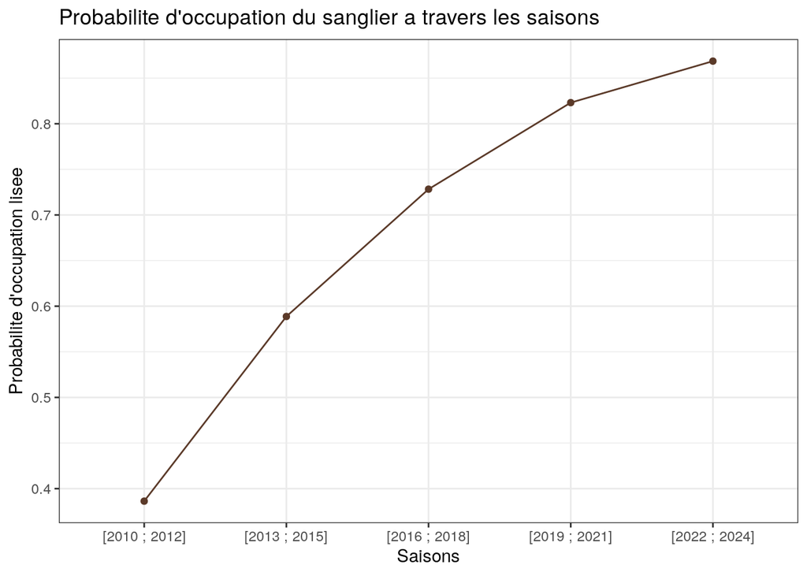

```r
plot +
      labs(title = "Probabilite d'occupation du sanglier a travers les saisons",
           x = "Saisons", y ="Probabilite d'occupation lisee")
```

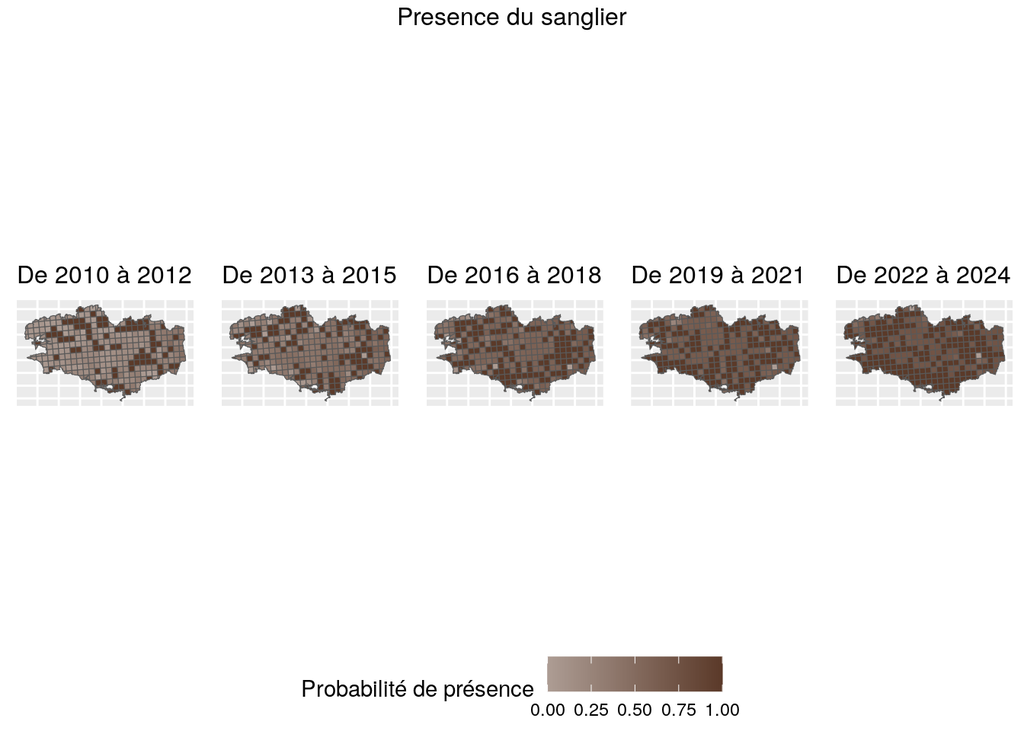

```r
    plot <- carte_graphique_5(fm=fm, couleur=couleur_sanglier)
    ggpubr::annotate_figure(plot,
                              top = ggpubr::text_grob("Presence du sanglier"))
```

## 2.2 Le renard roux

```r
    detection_matrice <- matrice_occu_detections(num_cd_nom = 60585)

    umf <- unmarkedFrameOccu(y = detection_matrice,
                             siteCovs = site_info)
```

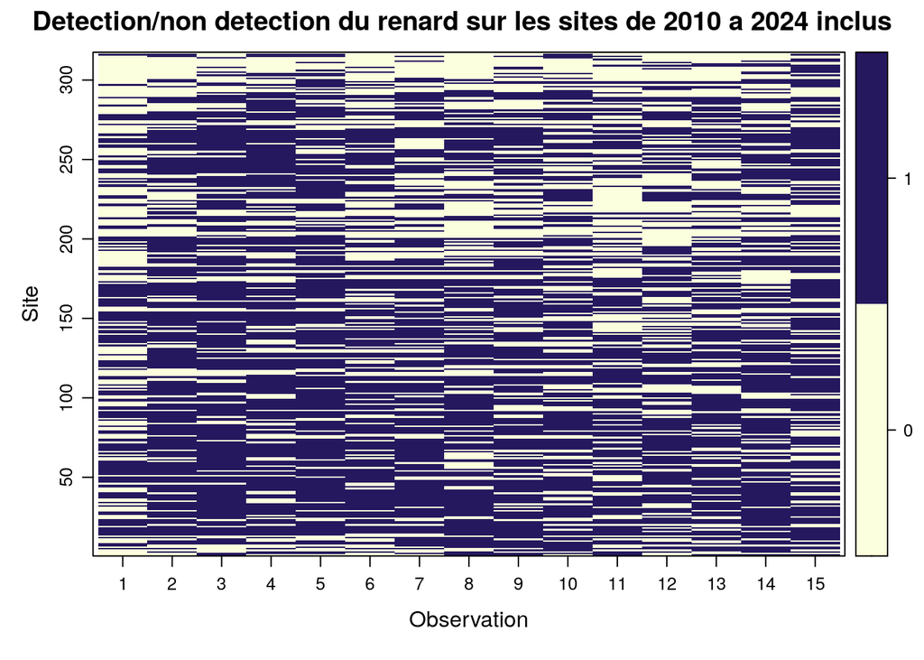

```r
    plot(umf,
         main="Detection/non detection du renard sur les sites de 2010 a 2024 inclus")
```

```r
    print(colSums(detection_matrice))
```

```
## 2010 2011 2012 2013 2014 2015 2016 2017 2018
##  144  211  232  213  231  188  200  186  200
## 2019 2020 2021 2022 2023 2024
##  191  167  175  189  199  208
```

```r
    pression_obs <- pression_obs_bdd(num_cd_nom = 60585)

    umf <- unmarked::unmarkedMultFrame(
      y = detection_matrice,
      siteCovs = site_info,
      obsCovs = list(pression_obs = pression_obs ),
      yearlySiteCovs = site_covs_periodes_5,
      numPrimary = 5
    )
    fm <- unmarked::colext(
    psiformula = ~ 1,     # initial occupancy
    gammaformula =  ~ quali_periodes,  # colonization
    epsilonformula = ~ quali_periodes, # extinction
    pformula = ~ pression_obs,  # detection
    data = umf, # data
    se = TRUE)
```

coefficients :

```r
    fm
```

```
##
## Call:
## unmarked::colext(psiformula = ~1, gammaformula = ~quali_periodes,
##     epsilonformula = ~quali_periodes, pformula = ~pression_obs,
##     data = umf, se = TRUE)
##
## Initial (logit-scale):
##  Estimate    SE    z  P(>|z|)
##       3.3 0.545 6.06 1.34e-09
##
## Colonization (logit-scale):
##                           Estimate   SE      z
## (Intercept)                 -0.912 1.75 -0.521
## quali_periodes2013 - 2015    0.304 2.39  0.127
## quali_periodes2016 - 2018    0.879 1.86  0.473
## quali_periodes2019-2021      3.625 3.31  1.097
##                           P(>|z|)
## (Intercept)                 0.603
## quali_periodes2013 - 2015   0.899
## quali_periodes2016 - 2018   0.636
## quali_periodes2019-2021     0.273
##
## Extinction (logit-scale):
##                           Estimate SE      z
## (Intercept)                  -9.48 23 -0.413
## quali_periodes2013 - 2015     6.76 23  0.294
## quali_periodes2016 - 2018     6.10 23  0.265
## quali_periodes2019-2021       5.04 23  0.219
##                           P(>|z|)
## (Intercept)                 0.680
## quali_periodes2013 - 2015   0.769
## quali_periodes2016 - 2018   0.791
## quali_periodes2019-2021     0.826
##
## Detection (logit-scale):
##              Estimate     SE    z  P(>|z|)
## (Intercept)     0.981 0.0465 21.1 7.80e-99
## pression_obs    2.015 0.0981 20.5 9.59e-94
##
## AIC: 5353.951
## Number of sites: 317
```

```r
    confint((fm_quali)[2])
```

```
##                          0.025    0.975
## col(Int)            -17.053560 4.321383
## col(quali_periodes)  -1.317121 5.484448
```

```r
    confint((fm_quali)[3])
```

```
##                          0.025     0.975
## ext(Int)            -4.9522790 -2.387292
## ext(quali_periodes) -0.5206872  0.455967
```

tests :

```r
    pb <- parboot(fm, statistic=chisq, nsim=40, parallel=FALSE)
```

```r
    pb
```

```
##
## Call: parboot(object = fm, statistic = chisq, nsim = 40, parallel = FALSE)
##
## Parametric Bootstrap Statistics:
##     t0 mean(t0 - t_B) StdDev(t0 - t_B) Pr(t_B > t0)
## 1 4531           -223              131        0.927
##
## t_B quantiles:
##        0% 2.5%  25%  50%  75% 97.5% 100%
## [1,] 4458 4527 4657 4773 4840  4973 5028
##
## t0 = Original statistic computed from data
## t_B = Vector of bootstrap samples
```

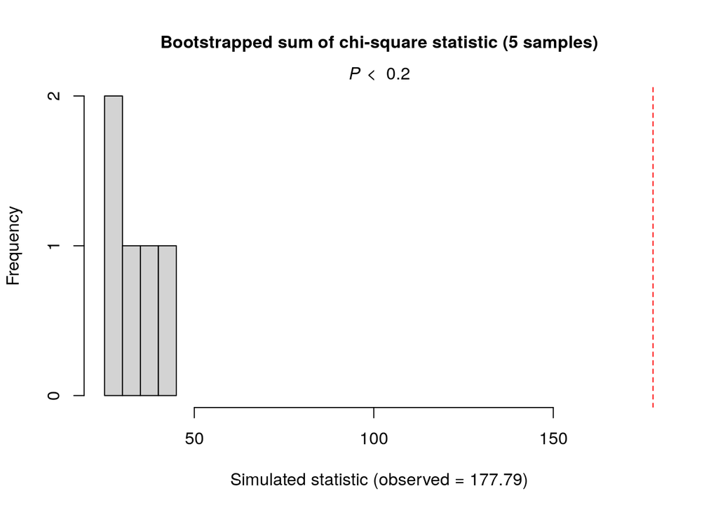

```
##
## Goodness-of-fit for dynamic occupancy model
##
## Number of seasons:  5
##
## Chi-square statistic:
## Season 1 Season 2 Season 3 Season 4 Season 5
##  94.2300  35.2578  20.6775  21.1882   6.4377
##
## Total chi-square = 177.7913
## Number of bootstrap samples = 5
## P-value = 0
##
## Quantiles of bootstrapped statistics:
##   0%  25%  50%  75% 100%
##   25   27   34   40   40
##
## Estimate of c-hat = 5.33
```

```r
    AICcmodavg::mb.gof.test(fm)
```

graphiques :

```r
    plot <- proba_graphique_5(fm = fm, couleur=couleur_renard)
```

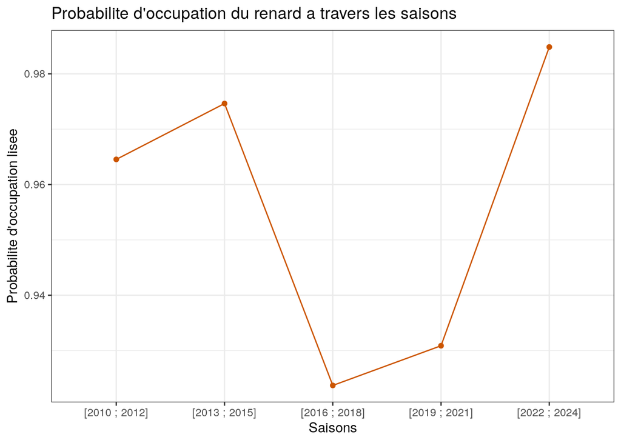

```r
    plot +
          labs(title = "Probabilite d'occupation du renard a travers les saisons",
               x = "Saisons", y ="Probabilite d'occupation lisee")
```

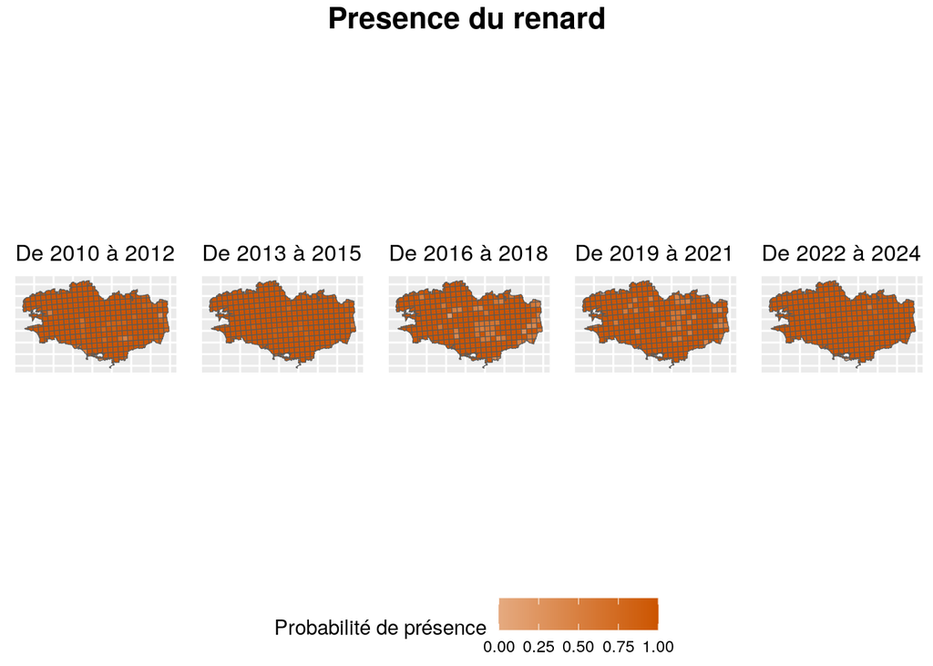

```r
    plot <- carte_graphique_5(fm=fm, couleur=couleur_renard)
    ggpubr::annotate_figure(plot,
                            top = ggpubr::text_grob("Presence du renard",
                                                    size = 16,
                                                    face = "bold"))
```

## 2.3 Le lapin de garenne

```r
    detection_matrice <- matrice_occu_detections(num_cd_nom = 61714)

    umf <- unmarkedFrameOccu(y = detection_matrice,
                             siteCovs = site_info)
```

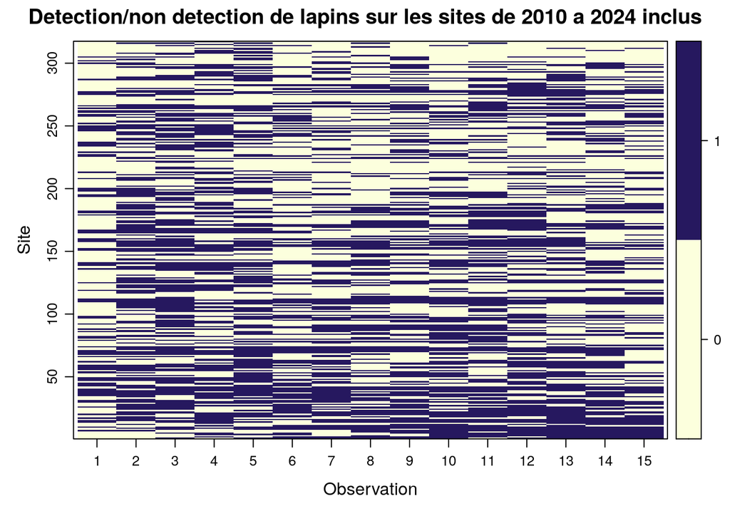

```r
    plot(umf,
         main="Detection/non detection de lapins sur les sites de 2010 a 2024 inclus")
```

```r
    print(colSums(detection_matrice))
```

```
## 2010 2011 2012 2013 2014 2015 2016 2017 2018 2019 2020 2021 2022 2023 2024
##   95  165  179  158  166  123  140  134  147  143  158  153  152  143  122
```

```r
    pression_obs <- pression_obs_bdd(num_cd_nom = 61714)

    umf <- unmarked::unmarkedMultFrame(
      y = detection_matrice,
      siteCovs = site_info,
      obsCovs = list(pression_obs = pression_obs),
      yearlySiteCovs = site_covs_periodes_5,
      numPrimary = 5
    )
  fm <- unmarked::colext(
    psiformula = ~ Dnst_Cultures + Dist_Littoral, # initial occupancy
    gammaformula =  ~ 1,  # colonization
    epsilonformula = ~ 1, # extinction
    pformula = ~ pression_obs,  # detection
    data = umf, # data
    control = list(trace = 1),
    se = TRUE)
```

coefficients :

```r
    fm
```

```
##
## Call:
## unmarked::colext(psiformula = ~Dnst_Cultures + Dist_Littoral,
##     gammaformula = ~1, epsilonformula = ~1, pformula = ~pression_obs,
##     data = umf, se = TRUE, control = list(trace = 1))
##
## Initial (logit-scale):
##               Estimate    SE     z  P(>|z|)
## (Intercept)      2.787 0.488  5.71 1.14e-08
## Dnst_Cultures   -0.805 0.366 -2.20 2.76e-02
## Dist_Littoral   -0.582 0.276 -2.11 3.47e-02
##
## Colonization (logit-scale):
##  Estimate    SE     z P(>|z|)
##    -0.464 0.274 -1.69  0.0906
##
## Extinction (logit-scale):
##  Estimate    SE     z  P(>|z|)
##     -2.59 0.224 -11.6 6.01e-31
##
## Detection (logit-scale):
##              Estimate     SE     z  P(>|z|)
## (Intercept)     0.179 0.0434  4.13 3.70e-05
## pression_obs    1.306 0.0720 18.14 1.57e-73
##
## AIC: 5676.804
## Number of sites: 317
```

```r
    backTransform(fm, "col"); confint(backTransform(fm, "col"))
```

```
## Backtransformed linear combination(s) of Colonization estimate(s)
##
##  Estimate    SE LinComb (Intercept)
##     0.386 0.065  -0.464           1
##
## Transformation: logistic
```

```
##      0.025     0.975
##  0.2684845 0.5183448
```

```r
    backTransform(fm, "ext"); confint(backTransform(fm, "ext"))
```

```
## Backtransformed linear combination(s) of Extinction estimate(s)
##
##  Estimate     SE LinComb (Intercept)
##    0.0699 0.0145   -2.59           1
##
## Transformation: logistic
```

```
##       0.025     0.975
##  0.04625461 0.1043954
```

tests :

```r
    pb <- parboot(fm, statistic=chisq, nsim=40, parallel=FALSE)
```

```r
    pb
```

```
##
## Call: parboot(object = fm, statistic = chisq, nsim = 40, parallel = FALSE)
##
## Parametric Bootstrap Statistics:
##     t0 mean(t0 - t_B) StdDev(t0 - t_B) Pr(t_B > t0)
## 1 4396           -365             73.9        0.976
##
## t_B quantiles:
##        0% 2.5%  25%  50%  75% 97.5% 100%
## [1,] 4640 4654 4727 4757 4792  4879 5089
##
## t0 = Original statistic computed from data
## t_B = Vector of bootstrap samples
```

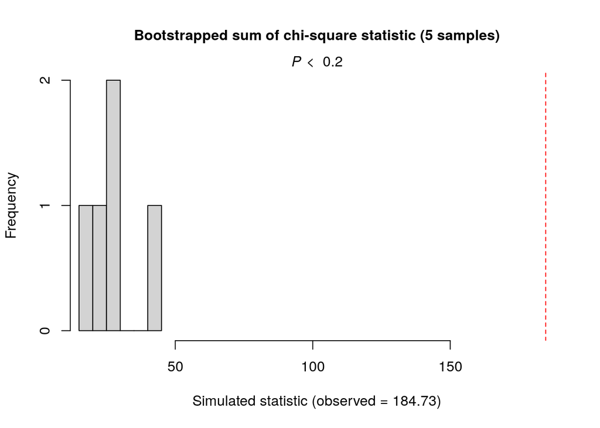

```
##
## Goodness-of-fit for dynamic occupancy model
##
## Number of seasons:  5
##
## Chi-square statistic:
## Season 1 Season 2 Season 3 Season 4 Season 5
##  73.5792  22.4731  35.0807  27.6131  25.9791
##
## Total chi-square = 184.7253
## Number of bootstrap samples = 5
## P-value = 0
##
## Quantiles of bootstrapped statistics:
##   0%  25%  50%  75% 100%
##   18   24   27   27   41
##
## Estimate of c-hat = 6.71
```

```r
    AICcmodavg::mb.gof.test(fm)
```

graphiques :

```r
    plot <- proba_graphique_5(fm, couleur=couleur_lapin)
```

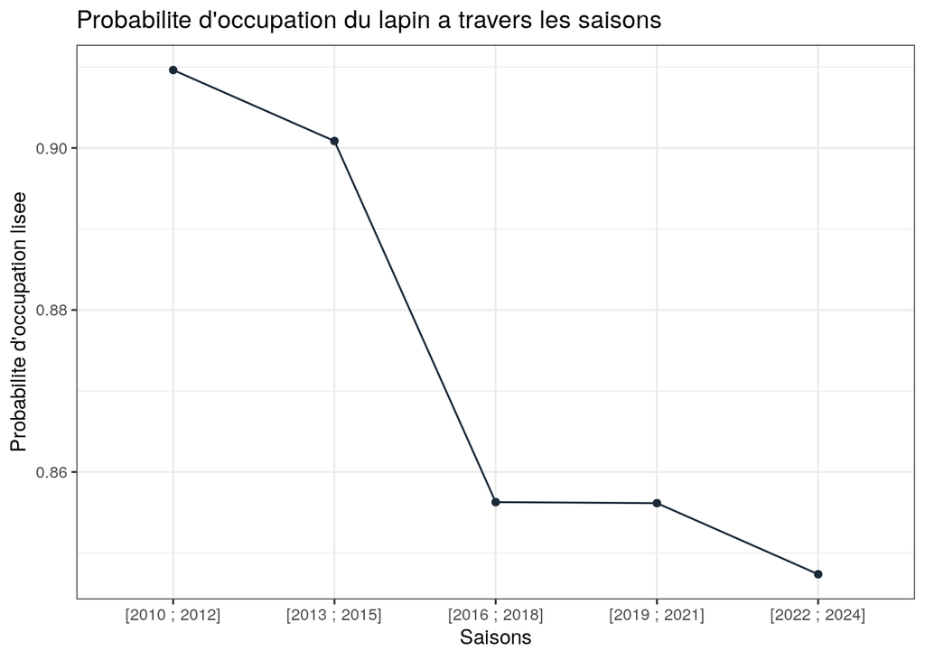

```r
    plot +
          labs(title = "Probabilite d'occupation du lapin a travers les saisons",
               x = "Saisons", y ="Probabilite d'occupation lisee")
```

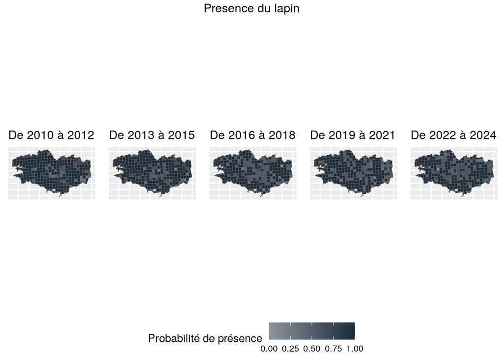

```r
        plot <- carte_graphique_5(fm=fm, couleur=couleur_lapin)
        ggpubr::annotate_figure(plot,
                                  top = ggpubr::text_grob("Presence du lapin"))
```

## 2.4 Le herisson

```r
    detection_matrice <- matrice_occu_detections(num_cd_nom = 60015)

    umf <- unmarkedFrameOccu(y = detection_matrice,
                             siteCovs = site_info)
```

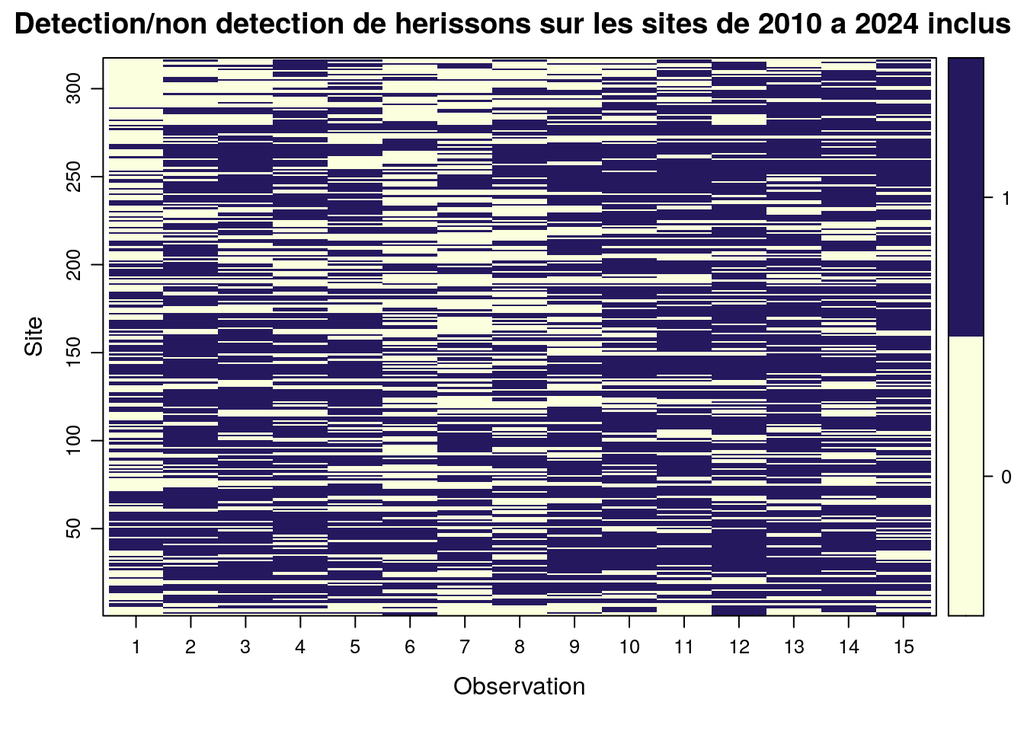

```r
    plot(umf,
         main="Detection/non detection de herissons sur les sites de 2010 a 2024 inclus")
```

```r
    print(colSums(detection_matrice))
```

```
## 2010 2011 2012 2013 2014 2015 2016 2017 2018 2019 2020 2021 2022 2023 2024
##  133  211  211  205  203  145  149  168  200  225  222  232  230  215  221
```

```r
    pression_obs <- pression_obs_bdd(num_cd_nom = 60015)

    umf <- unmarked::unmarkedMultFrame(
      y = detection_matrice,
      siteCovs = site_info,
      obsCovs = list(pression_obs = pression_obs ),
      yearlySiteCovs = site_covs_periodes_5,
      numPrimary = 5
    )
  fm <- unmarked::colext(
    psiformula = ~ X_10km + Dist_EcotoneArbore, # initial occupancy
    gammaformula =  ~ 1,  # colonization
    epsilonformula = ~ 1, # extinction
    pformula = ~ pression_obs,  # detection
    data = umf, # data
    control = list(trace = 1),
    se = TRUE)
```

coefficients :

```r
    fm
```

```
##
## Call:
## unmarked::colext(psiformula = ~X_10km + Dist_EcotoneArbore, gammaformula = ~1,
##     epsilonformula = ~1, pformula = ~pression_obs, data = umf,
##     se = TRUE, control = list(trace = 1))
##
## Initial (logit-scale):
##                    Estimate    SE     z  P(>|z|)
## (Intercept)            5.06 1.271  3.98 6.82e-05
## X_10km                -3.14 0.921 -3.41 6.52e-04
## Dist_EcotoneArbore    -1.43 0.409 -3.49 4.89e-04
##
## Colonization (logit-scale):
##  Estimate   SE    z P(>|z|)
##     0.626 0.27 2.32  0.0203
##
## Extinction (logit-scale):
##  Estimate   SE     z  P(>|z|)
##     -3.01 0.22 -13.7 8.81e-43
##
## Detection (logit-scale):
##              Estimate     SE    z   P(>|z|)
## (Intercept)     0.955 0.0432 22.1 3.67e-108
## pression_obs    1.467 0.0878 16.7  1.00e-62
##
## AIC: 5513.156
## Number of sites: 317
```

```r
    backTransform(fm, "col"); confint(backTransform(fm, "col"))
```

```
## Backtransformed linear combination(s) of Colonization estimate(s)
##
##  Estimate     SE LinComb (Intercept)
##     0.652 0.0613   0.626           1
##
## Transformation: logistic
```

```
##    0.025     0.975
##  0.52429 0.7604752
```

```r
    backTransform(fm, "ext"); confint(backTransform(fm, "ext"))
```

```
## Backtransformed linear combination(s) of Extinction estimate(s)
##
##  Estimate      SE LinComb (Intercept)
##     0.047 0.00983   -3.01           1
##
## Transformation: logistic
```

```
##       0.025      0.975
##  0.03107151 0.07047576
```

tests :

```r
    pb <- parboot(fm, statistic=chisq, nsim=40, parallel=FALSE)
```

```r
    pb
```

```
##
## Call: parboot(object = fm, statistic = chisq, nsim = 40, parallel = FALSE)
##
## Parametric Bootstrap Statistics:
##     t0 mean(t0 - t_B) StdDev(t0 - t_B) Pr(t_B > t0)
## 1 4477           -280             86.1        0.976
##
## t_B quantiles:
##        0% 2.5%  25%  50%  75% 97.5% 100%
## [1,] 4638 4638 4702 4755 4790  4931 5087
##
## t0 = Original statistic computed from data
## t_B = Vector of bootstrap samples
```

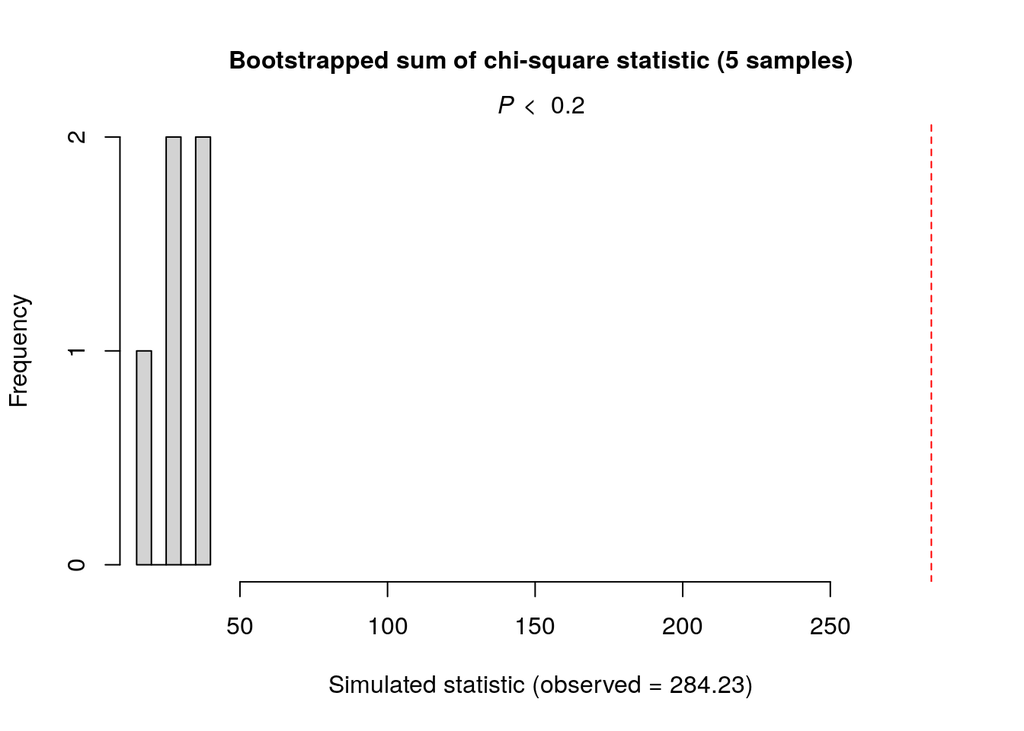

```
##
## Goodness-of-fit for dynamic occupancy model
##
## Number of seasons:  5
##
## Chi-square statistic:
## Season 1 Season 2 Season 3 Season 4 Season 5
##  93.9007  52.8810  54.4485  42.5554  40.4452
##
## Total chi-square = 284.2308
## Number of bootstrap samples = 5
## P-value = 0
##
## Quantiles of bootstrapped statistics:
##   0%  25%  50%  75% 100%
##   20   26   30   36   38
##
## Estimate of c-hat = 9.5
```

```r
    AICcmodavg::mb.gof.test(fm)
```

graphiques :

```r
    plot <- proba_graphique_5(fm=fm, couleur=couleur_herisson)
```

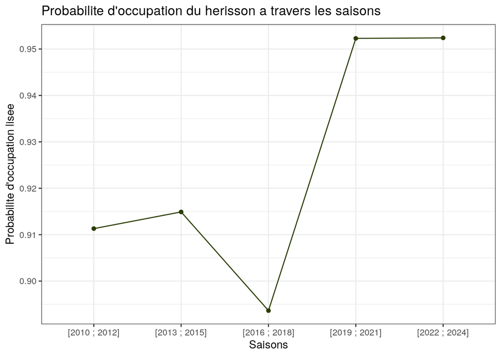

```r
    plot +
          labs(title = "Probabilite d'occupation du herisson a travers les saisons",
               x = "Saisons", y ="Probabilite d'occupation lisee")
```

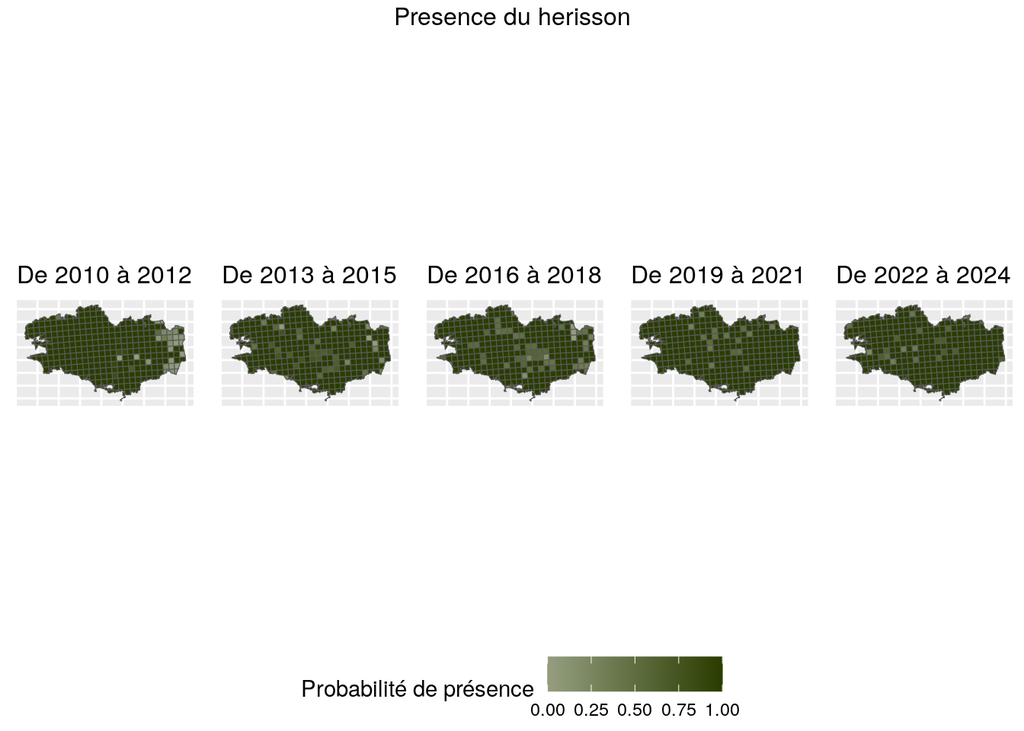

```r
        plot <- carte_graphique_5(fm=fm, couleur=couleur_herisson)
        ggpubr::annotate_figure(plot,
                                  top = ggpubr::text_grob("Presence du herisson"))
```

## 2.5 Le putois

```r
    detection_matrice <- matrice_occu_detections(num_cd_nom = 60731)

    umf <- unmarkedFrameOccu(y = detection_matrice,
                             siteCovs = site_info)
```

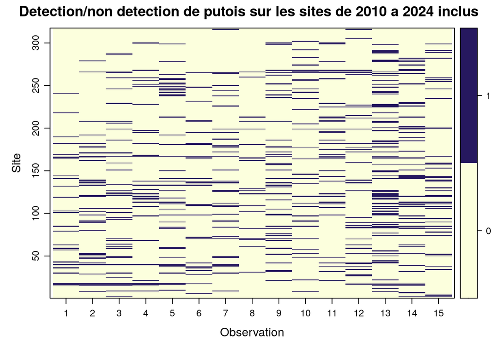

```r
    plot(umf,
         main="Detection/non detection de putois sur les sites de 2010 a 2024 inclus")
```

```r
    print(colSums(detection_matrice))
```

```
## 2010 2011 2012 2013 2014 2015 2016 2017 2018 2019 2020 2021 2022 2023 2024
##   25   34   38   29   40   26   34   18   39   32   36   35   74   48   38
```

```r
    pression_obs <- pression_obs_bdd(num_cd_nom = 60731)

    umf <- unmarked::unmarkedMultFrame(
      y = detection_matrice,
      siteCovs = site_info,
      obsCovs = list(pression_obs = pression_obs ),
      yearlySiteCovs = site_covs_periodes_3,
      numPrimary = 3
    )
    fm <- unmarked::colext(
      psiformula = ~ X_10km + Y_10km, # initial occupancy
      gammaformula =  ~ 1,  # colonization
      epsilonformula = ~ 1, # extinction
      pformula = ~ scale(pression_obs),  # detection
      data = umf, # data
      control = list(trace = 1),
      se = TRUE)
```

coefficients :

```r
    fm
```

```
##
## Call:
## unmarked::colext(psiformula = ~X_10km + Y_10km, gammaformula = ~1,
##     epsilonformula = ~1, pformula = ~scale(pression_obs), data = umf,
##     se = TRUE, control = list(trace = 1))
##
## Initial (logit-scale):
##             Estimate    SE     z P(>|z|)
## (Intercept)    0.590 0.256  2.31 0.02100
## X_10km        -0.659 0.253 -2.60 0.00921
## Y_10km         0.306 0.195  1.56 0.11777
##
## Colonization (logit-scale):
##  Estimate   SE     z P(>|z|)
##    -0.439 0.29 -1.51    0.13
##
## Extinction (logit-scale):
##  Estimate    SE     z  P(>|z|)
##     -2.25 0.568 -3.97 7.21e-05
##
## Detection (logit-scale):
##                     Estimate     SE      z   P(>|z|)
## (Intercept)           -1.705 0.0788 -21.65 6.47e-104
## scale(pression_obs)    0.514 0.0556   9.25  2.28e-20
##
## AIC: 3188.103
## Number of sites: 317
```

```r
    backTransform(fm, "col"); confint(backTransform(fm, "col"))
```

```
## Backtransformed linear combination(s) of Colonization estimate(s)
##
##  Estimate     SE LinComb (Intercept)
##     0.392 0.0691  -0.439           1
##
## Transformation: logistic
```

```
##      0.025     0.975
##  0.2674496 0.5322228
```

```r
    backTransform(fm, "ext"); confint(backTransform(fm, "ext"))
```

```
## Backtransformed linear combination(s) of Extinction estimate(s)
##
##  Estimate     SE LinComb (Intercept)
##    0.0951 0.0488   -2.25           1
##
## Transformation: logistic
```

```
##       0.025     0.975
##  0.03340381 0.2422444
```

tests :

```r
    pb <- parboot(fm, statistic=chisq, nsim=40, parallel=FALSE)
```

```r
    pb
```

```
##
## Call: parboot(object = fm, statistic = chisq, nsim = 40, parallel = FALSE)
##
## Parametric Bootstrap Statistics:
##     t0 mean(t0 - t_B) StdDev(t0 - t_B) Pr(t_B > t0)
## 1 4526           -240               38        0.976
##
## t_B quantiles:
##        0% 2.5%  25%  50%  75% 97.5% 100%
## [1,] 4693 4695 4736 4767 4792  4837 4851
##
## t0 = Original statistic computed from data
## t_B = Vector of bootstrap samples
```

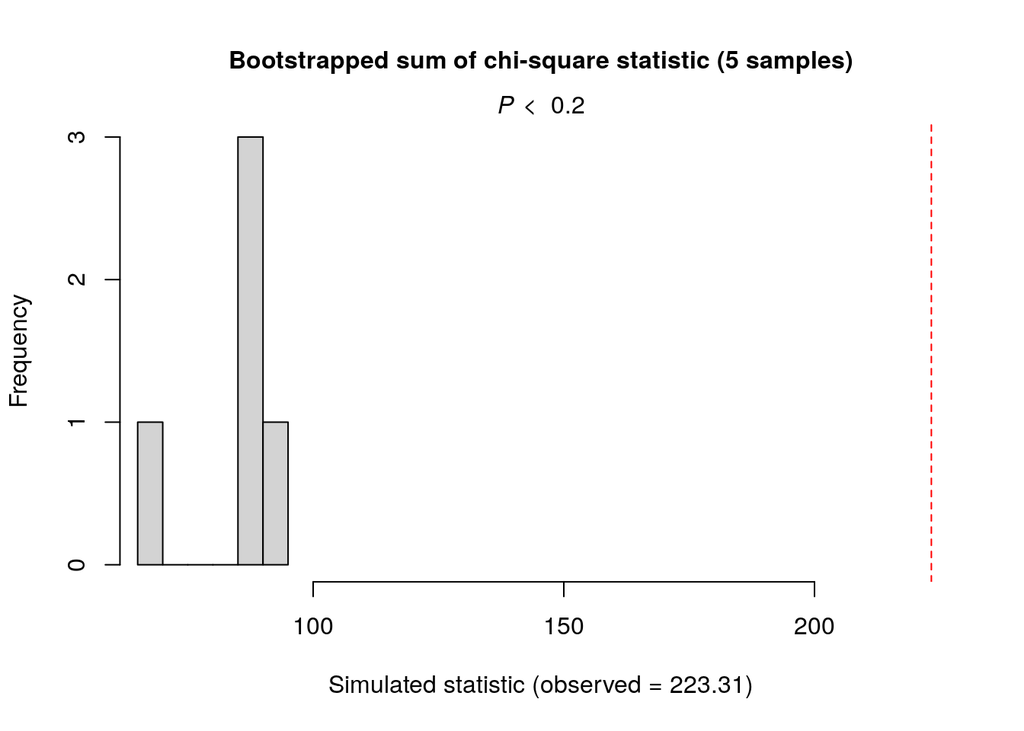

```
##
## Goodness-of-fit for dynamic occupancy model
##
## Number of seasons:  3
##
## Chi-square statistic:
## Season 1 Season 2 Season 3
## 113.4182  32.9396  76.9479
##
## Total chi-square = 223.3057
## Number of bootstrap samples = 5
## P-value = 0
##
## Quantiles of bootstrapped statistics:
##   0%  25%  50%  75% 100%
##   68   85   86   89   92
##
## Estimate of c-hat = 2.66
```

```r
    AICcmodavg::mb.gof.test(fm)
```

graphiques :

```r
    plot <- proba_graphique_3(fm=fm, couleur=couleur_putois)
```

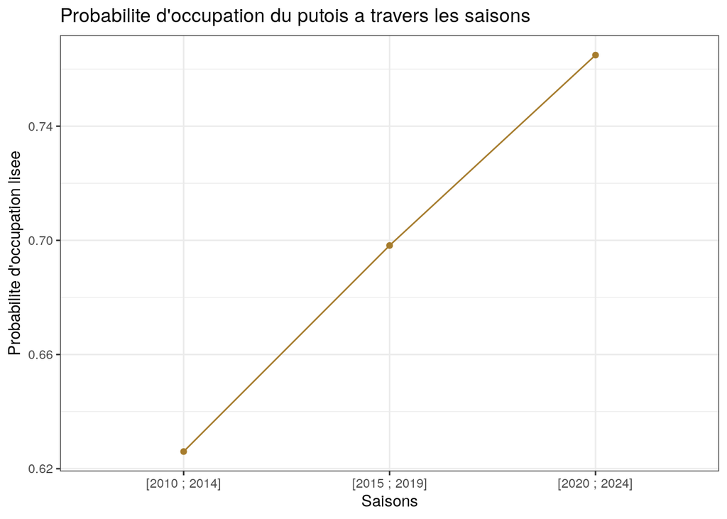

```r
    plot +
          labs(title = "Probabilite d'occupation du putois a travers les saisons",
               x = "Saisons", y ="Probabilite d'occupation lisee")
```

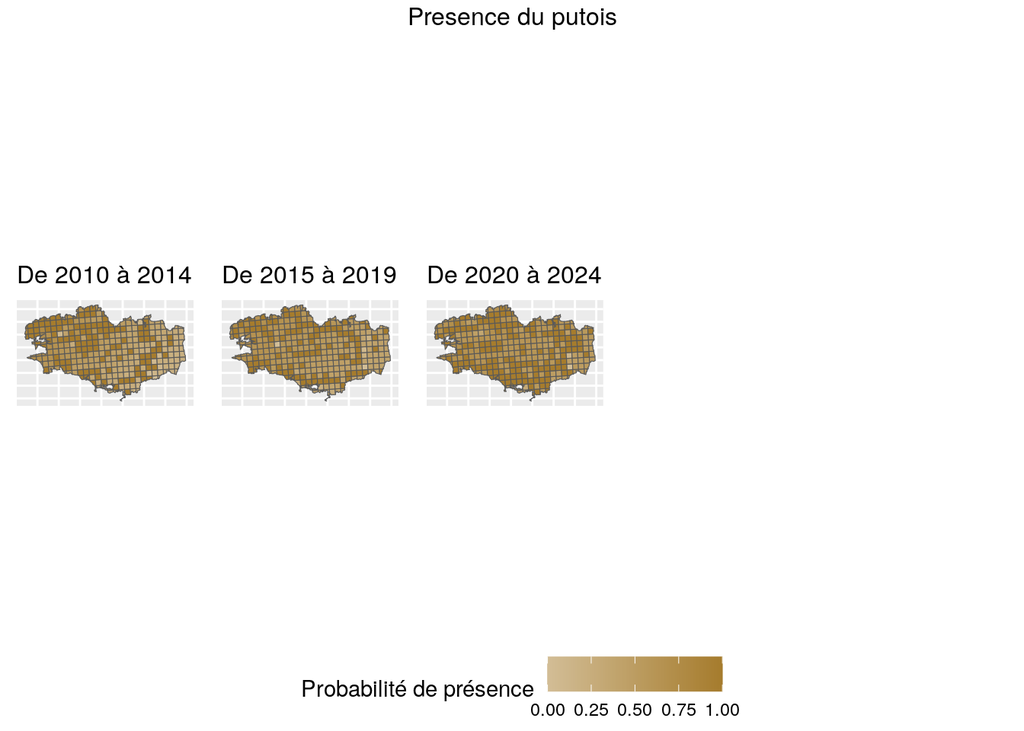

```r
        plot <- carte_graphique_3(fm=fm, couleur=couleur_putois)
        ggpubr::annotate_figure(plot,
                                  top = ggpubr::text_grob("Presence du putois"))
```

## 2.6 L’hermine

```r
    detection_matrice <- matrice_occu_detections(num_cd_nom = 60686)

    umf <- unmarkedFrameOccu(y = detection_matrice,
                             siteCovs = site_info)
```

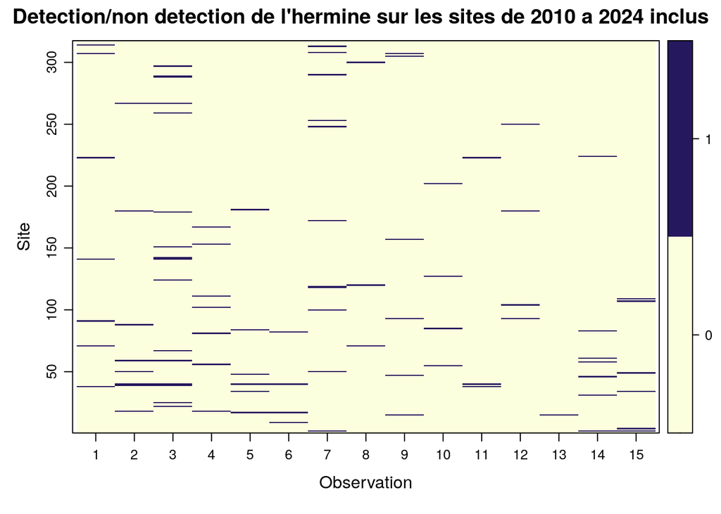

```r
    plot(umf,
         main="Detection/non detection de l'hermine sur les sites de 2010 a 2024 inclus")
```

```r
    print(colSums(detection_matrice))
```

```
## 2010 2011 2012 2013 2014 2015 2016 2017 2018 2019 2020 2021 2022 2023 2024
##    7    8   16    7    6    4   11    3    6    4    3    4    1    7    6
```

```r
    pression_obs <- pression_obs_bdd(num_cd_nom = 60686)

    umf <- unmarked::unmarkedMultFrame(
      y = detection_matrice,
      siteCovs = site_info,
      obsCovs = list(pression_obs = pression_obs ),
      yearlySiteCovs = site_covs_periodes_3,
      numPrimary = 3
    )
    fm <- unmarked::colext(
      psiformula = ~ Y_10km + Dist_Eau, # initial occupancy
      gammaformula =  ~ 1,  # colonization
      epsilonformula = ~ 1, # extinction
      pformula = ~ pression_obs,  # detection
      data = umf, # data
      control = list(trace = 1),
      se = TRUE)
```

coefficients :

```r
    fm
```

```
##
## Call:
## unmarked::colext(psiformula = ~Y_10km + Dist_Eau, gammaformula = ~1,
##     epsilonformula = ~1, pformula = ~pression_obs, data = umf,
##     se = TRUE, control = list(trace = 1))
##
## Initial (logit-scale):
##             Estimate    SE     z  P(>|z|)
## (Intercept)    0.237 0.430  0.55 0.582457
## Y_10km         1.274 0.381  3.34 0.000834
## Dist_Eau      -0.870 0.395 -2.20 0.027615
##
## Colonization (logit-scale):
##  Estimate   SE      z P(>|z|)
##     -7.72 22.1 -0.349   0.727
##
## Extinction (logit-scale):
##  Estimate   SE     z P(>|z|)
##     -1.11 0.48 -2.31   0.021
##
## Detection (logit-scale):
##              Estimate     SE      z  P(>|z|)
## (Intercept)    -3.055 0.1889 -16.17 7.90e-59
## pression_obs    0.205 0.0997   2.05 4.02e-02
##
## AIC: 889.8304
## Number of sites: 317
```

```r
    backTransform(fm, "col"); confint(backTransform(fm, "col"))
```

```
## Backtransformed linear combination(s) of Colonization estimate(s)
##
##  Estimate      SE LinComb (Intercept)
##  0.000443 0.00979   -7.72           1
##
## Transformation: logistic
```

```
##         0.025 0.975
##  6.843246e-23     1
```

```r
    backTransform(fm, "ext"); confint(backTransform(fm, "ext"))
```

```
## Backtransformed linear combination(s) of Extinction estimate(s)
##
##  Estimate     SE LinComb (Intercept)
##     0.248 0.0896   -1.11           1
##
## Transformation: logistic
```

```
##      0.025     0.975
##  0.1141156 0.4583408
```

tests :

```r
    pb <- parboot(fm, statistic=chisq, nsim=40, parallel=FALSE)
```

```r
    pb
```

```
##
## Call: parboot(object = fm, statistic = chisq, nsim = 40, parallel = FALSE)
##
## Parametric Bootstrap Statistics:
##     t0 mean(t0 - t_B) StdDev(t0 - t_B) Pr(t_B > t0)
## 1 4391           -220              262        0.732
##
## t_B quantiles:
##        0% 2.5%  25%  50%  75% 97.5% 100%
## [1,] 4007 4144 4419 4604 4798  5077 5283
##
## t0 = Original statistic computed from data
## t_B = Vector of bootstrap samples
```

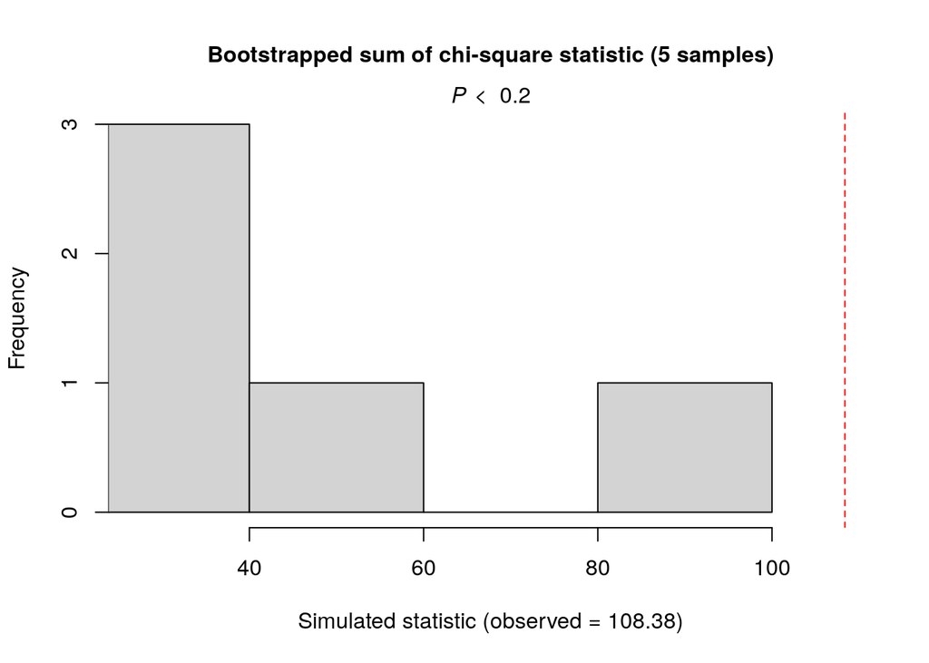

```
##
## Goodness-of-fit for dynamic occupancy model
##
## Number of seasons:  3
##
## Chi-square statistic:
## Season 1 Season 2 Season 3
##  87.6708  11.2945   9.4118
##
## Total chi-square = 108.3771
## Number of bootstrap samples = 5
## P-value = 0
##
## Quantiles of bootstrapped statistics:
##   0%  25%  50%  75% 100%
##   27   27   36   40   99
##
## Estimate of c-hat = 2.36
```

```r
    AICcmodavg::mb.gof.test(fm)
```

graphiques :

```r
plot <- proba_graphique_3(fm=fm, couleur=couleur_hermine)
```

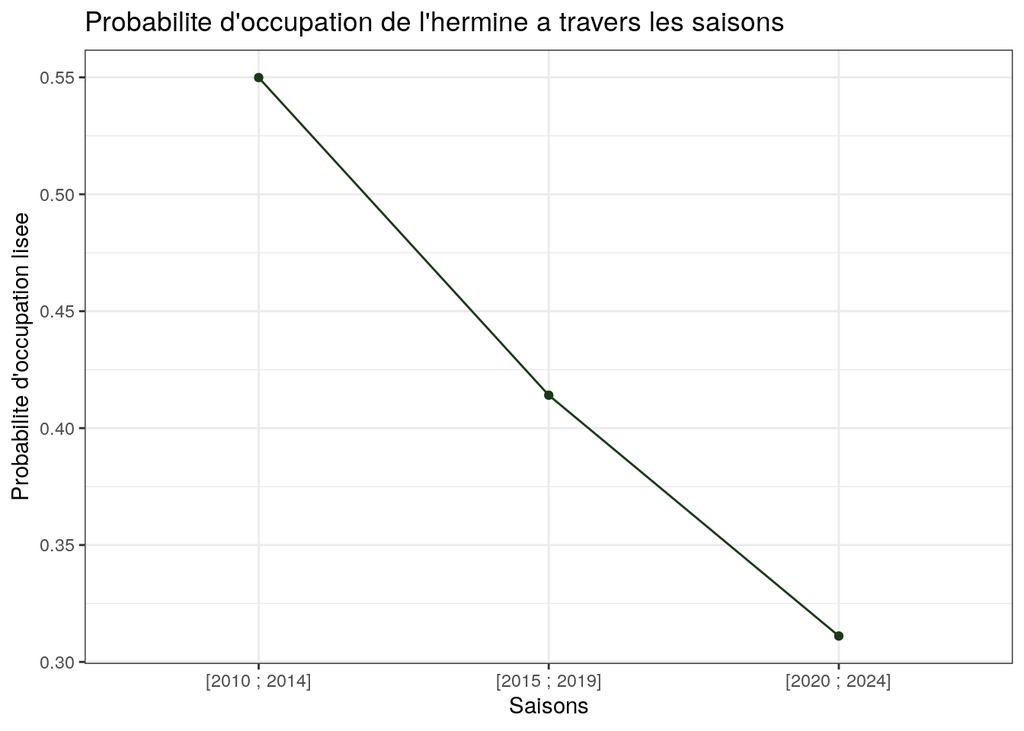

```r
plot +
      labs(title = "Probabilite d'occupation de l'hermine a travers les saisons",
           x = "Saisons", y ="Probabilite d'occupation lisee")
```

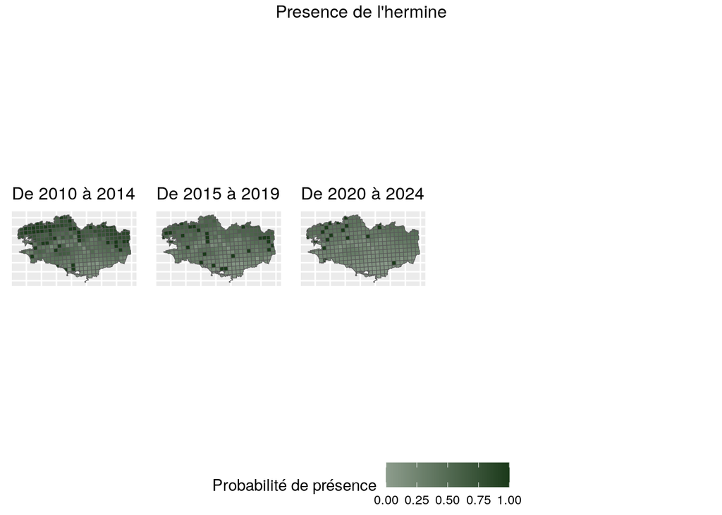

```r
    plot <- carte_graphique_3(fm=fm, couleur=couleur_hermine)
    ggpubr::annotate_figure(plot,
                              top = ggpubr::text_grob("Presence de l'hermine"))
```

## 2.7 La fouine

```r
    detection_matrice <- matrice_occu_detections(num_cd_nom = 60674)

    umf <- unmarkedFrameOccu(y = detection_matrice,
                             siteCovs = site_info)
```

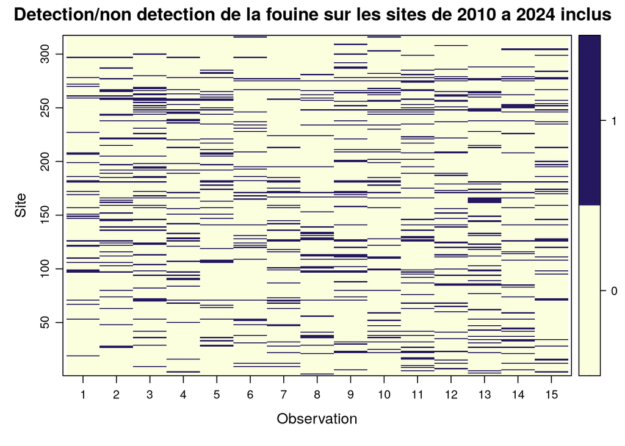

```r
    plot(umf,
         main="Detection/non detection de la fouine sur les sites de 2010 a 2024 inclus")
```

```r
    print(colSums(detection_matrice))
```

```
## 2010 2011 2012 2013 2014 2015 2016 2017 2018 2019 2020 2021 2022 2023 2024
##   31   44   52   39   42   33   38   36   46   43   50   44   51   39   42
```

```r
    pression_obs <- pression_obs_bdd(num_cd_nom = 60674)

    umf <- unmarked::unmarkedMultFrame(
      y = detection_matrice,
      siteCovs = site_info,
      obsCovs = list(pression_obs = pression_obs ),
      yearlySiteCovs = site_covs_periodes_3,
      numPrimary = 3
    )
    fm <- unmarked::colext(
      psiformula = ~ Dist_EcotoneArbore + Dist_Littoral, # initial occupancy
      gammaformula =  ~ 1,  # colonization
      epsilonformula = ~ 1, # extinction
      pformula = ~ pression_obs,  # detection
      data = umf, # data
      control = list(trace = 1),
      se = TRUE)
```

coefficients :

```r
    fm
```

```
##
## Call:
## unmarked::colext(psiformula = ~Dist_EcotoneArbore + Dist_Littoral,
##     gammaformula = ~1, epsilonformula = ~1, pformula = ~pression_obs,
##     data = umf, se = TRUE, control = list(trace = 1))
##
## Initial (logit-scale):
##                    Estimate    SE     z P(>|z|)
## (Intercept)           0.602 0.207  2.91 0.00359
## Dist_EcotoneArbore   -0.524 0.196 -2.67 0.00758
## Dist_Littoral        -0.358 0.178 -2.01 0.04481
##
## Colonization (logit-scale):
##  Estimate    SE     z P(>|z|)
##    -0.641 0.276 -2.32  0.0203
##
## Extinction (logit-scale):
##  Estimate    SE     z P(>|z|)
##     -2.22 0.489 -4.55 5.4e-06
##
## Detection (logit-scale):
##              Estimate     SE      z   P(>|z|)
## (Intercept)    -1.515 0.0704 -21.52 9.22e-103
## pression_obs    0.535 0.0557   9.61  7.21e-22
##
## AIC: 3472.647
## Number of sites: 317
```

```r
    backTransform(fm, "col"); confint(backTransform(fm, "col"))
```

```
## Backtransformed linear combination(s) of Colonization estimate(s)
##
##  Estimate     SE LinComb (Intercept)
##     0.345 0.0624  -0.641           1
##
## Transformation: logistic
```

```
##      0.025     0.975
##  0.2345676 0.4750792
```

```r
    backTransform(fm, "ext"); confint(backTransform(fm, "ext"))
```

```
## Backtransformed linear combination(s) of Extinction estimate(s)
##
##  Estimate     SE LinComb (Intercept)
##    0.0977 0.0431   -2.22           1
##
## Transformation: logistic
```

```
##       0.025     0.975
##  0.03987518 0.2200715
```

tests :

```r
    pb <- parboot(fm, statistic=chisq, nsim=40, parallel=FALSE)
```

```r
    pb
```

```
##
## Call: parboot(object = fm, statistic = chisq, nsim = 40, parallel = FALSE)
##
## Parametric Bootstrap Statistics:
##     t0 mean(t0 - t_B) StdDev(t0 - t_B) Pr(t_B > t0)
## 1 4566           -190               34        0.976
##
## t_B quantiles:
##        0% 2.5%  25%  50%  75% 97.5% 100%
## [1,] 4674 4709 4733 4749 4780  4824 4837
##
## t0 = Original statistic computed from data
## t_B = Vector of bootstrap samples
```

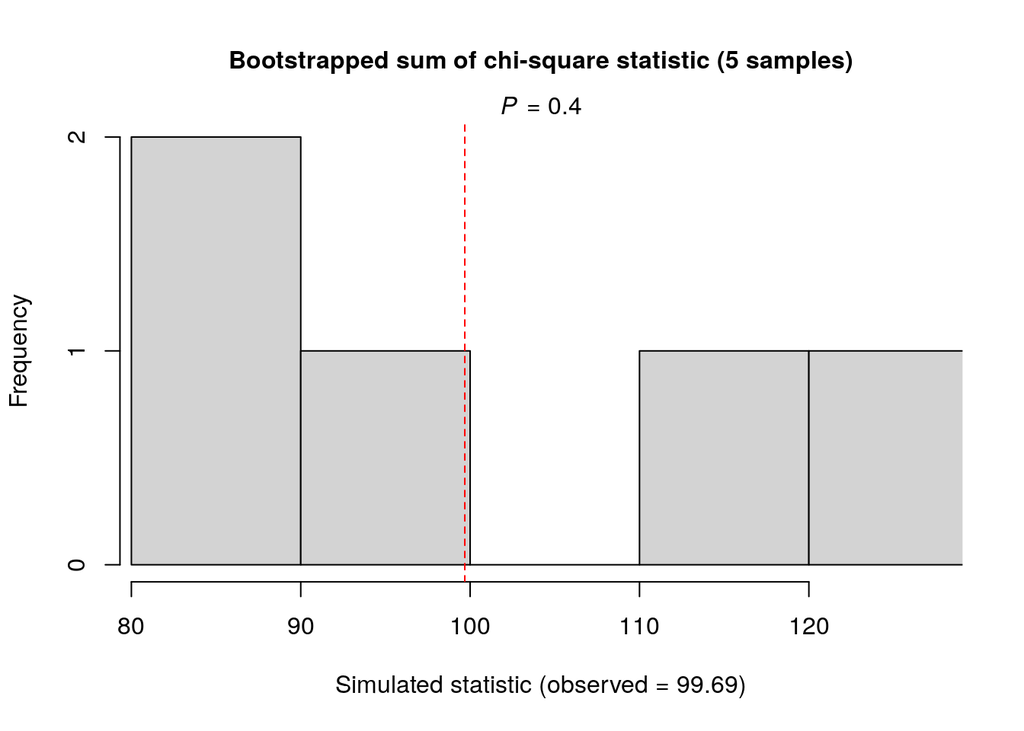

```
##
## Goodness-of-fit for dynamic occupancy model
##
## Number of seasons:  3
##
## Chi-square statistic:
## Season 1 Season 2 Season 3
##  33.5619  34.8895  31.2344
##
## Total chi-square = 99.6858
## Number of bootstrap samples = 5
## P-value = 0.4
##
## Quantiles of bootstrapped statistics:
##   0%  25%  50%  75% 100%
##   81   89   95  112  127
##
## Estimate of c-hat = 0.99
```

```r
    AICcmodavg::mb.gof.test(fm)
```

graphiques :

```r
    plot <- proba_graphique_3(fm=fm, couleur=couleur_fouine)
```

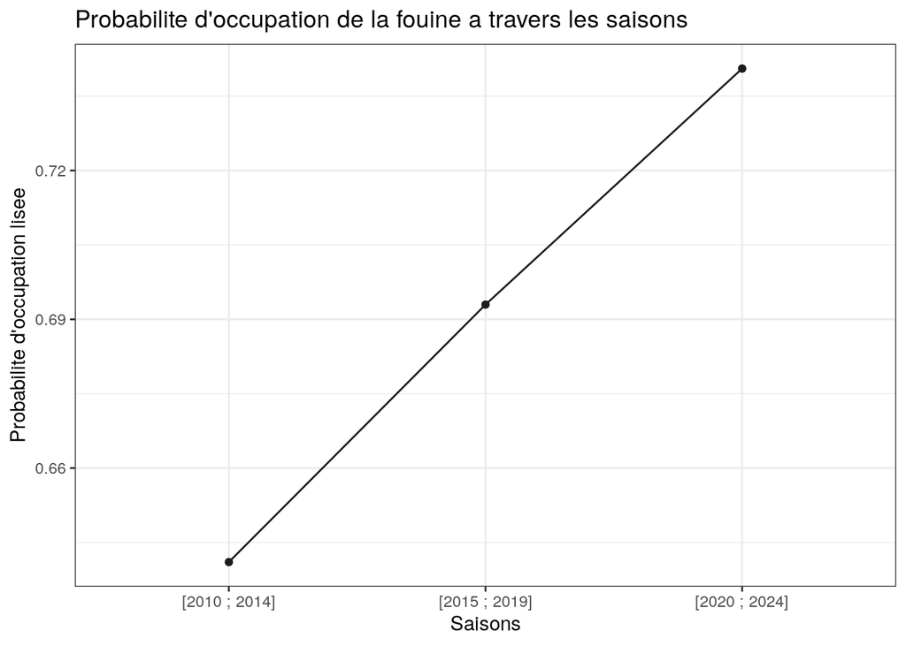

```r
    plot +
          labs(title = "Probabilite d'occupation de la fouine a travers les saisons",
               x = "Saisons", y ="Probabilite d'occupation lisee")
```

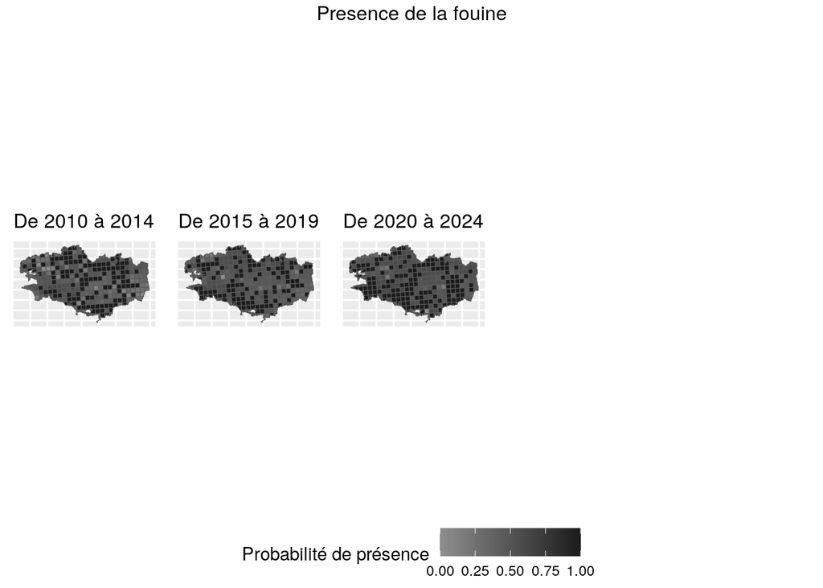

```r
        plot <- carte_graphique_3(fm=fm, couleur=couleur_fouine)
        ggpubr::annotate_figure(plot,
                                  top = ggpubr::text_grob("Presence de la fouine"))
```